# Tal og data fra KUB Datalab

Det ser lidt skævt ud. Man kunne få den tanke at mænd er underrepræsenterede på vores kurser. Vi har tælletal, og vi har to kategoriske variable. Så vi kan køre en chi i anden test, hvor vi ser om der faktisk er forskel på fordelingerne. Er p-værdien under 0.05, er der forskel.

```r
p_værdi <- all_events %>%
  select(id, start) %>%
  distinct() %>%
  left_join(master_data, by=c("id"="event_id")) %>%
  filter(year(start) > 2021) %>%
  select(id, start, liste, booking_id, køn) %>%
  filter(!is.na(liste)) %>%
  mutate(køn=case_when(
    køn > 0.5 ~ "Male",
    køn <= 0.5 ~ "Female",
    is.na(køn) ~ "Ukendt"
  )) %>%
  group_by(køn) %>%
  summarise(antal = n()) %>%
  mutate(andel = case_when(
    køn == "Ukendt" ~ NA_real_,
    TRUE ~ as.numeric(antal)
  )) %>%
  mutate(andel = andel/sum(andel, na.rm=T)*100) %>%
  mutate(andel_ku = c(
    23022,
    13875,
    NA_real_
  )) %>%
  filter(!is.na(andel)) %>%
  select(-andel) %>%
  select(-køn) %>%
  as.matrix() %>%
  chisq.test() %>%
  .$p.value
```

p-værdien er 8.2805009^{-16}, og ud fra det kan vi konkludere at mænd er underrepræsenterede på vores kurser.

Hvordan ser udviklingen over tid ud?

Pas på! i skrivende stund har vi ikke mange datapunkter, så fremskrivninger skal tages med et gram salt (eller to):

[output not shown]

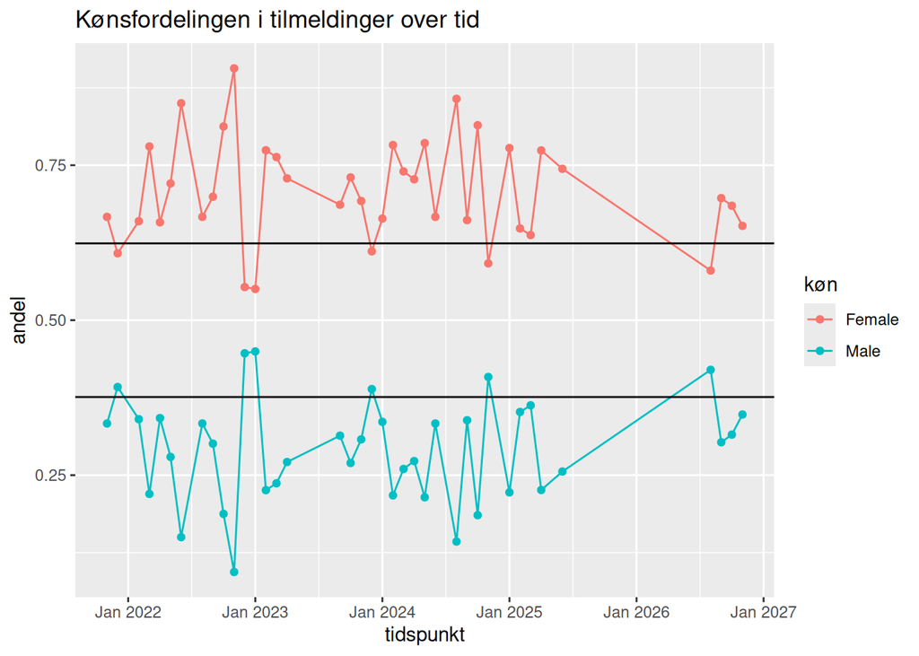

## Kategorier

Vi tildeler ved oprettelsen af kurser forskellige kategorier. De får (ca) alle kategorien datalab. Vi har, nogenlunde, systematisk tildelt dem kategorien English. “Online Course” har vi tydeligvis ikke brugt synderligt systematisk. Og det er derudover noget hø at vi ikke kan udnytte kalendersystemets muligheder for integration med Zoom.

Rant over - en del kurser har mere end en kategori. Tallene summer derfor ikke nødvendigvis til det du synes de skal summe til.

```r
all_events %>%
  select(id, start, category_name) %>%
  group_by(category_name) %>%
  summarise(antal = n())
```

```
## # A tibble: 11 × 2
##    category_name antal
##    <chr>         <int>
##  1 Analysis       3472
##  2 Cleaning       1634
##  3 Datalab        4364
##  4 English        2781
##  5 Harvesting      844
##  6 Online course    90
##  7 Python          555
##  8 R               317
##  9 Summer School    73
## 10 Visualisation  1039
## 11 <NA>              3
```

Det er nok overvejende de fire søjler vi er interesserede i.

```r
interessante_kategorier <- c("Analysis","Cleaning","Harvesting","Visualisation")
all_events %>%
  select(id, start, category_name) %>%
  filter(category_name %in% interessante_kategorier) %>%
  group_by(category_name) %>%
  summarise(antal = n())
```

```
## # A tibble: 4 × 2
##   category_name antal
##   <chr>         <int>
## 1 Analysis       3472
## 2 Cleaning       1634
## 3 Harvesting      844
## 4 Visualisation  1039
```

Hvordan med antal deltagere fordelt på kategorierne?

```r
all_events %>%
  select(id, start, category_name) %>%
  filter(category_name %in% interessante_kategorier) %>%
  left_join(master_data, by=c("id"="event_id")) %>%
  select(id, start, category_name, booking_id) %>%
  group_by(category_name) %>%
  summarise(antal = n())
```

```
## # A tibble: 4 × 2
##   category_name antal
##   <chr>         <int>
## 1 Analysis      64308
## 2 Cleaning      28796
## 3 Harvesting     3369
## 4 Visualisation  5751
```

Hvordan vokser tilmeldingerne?

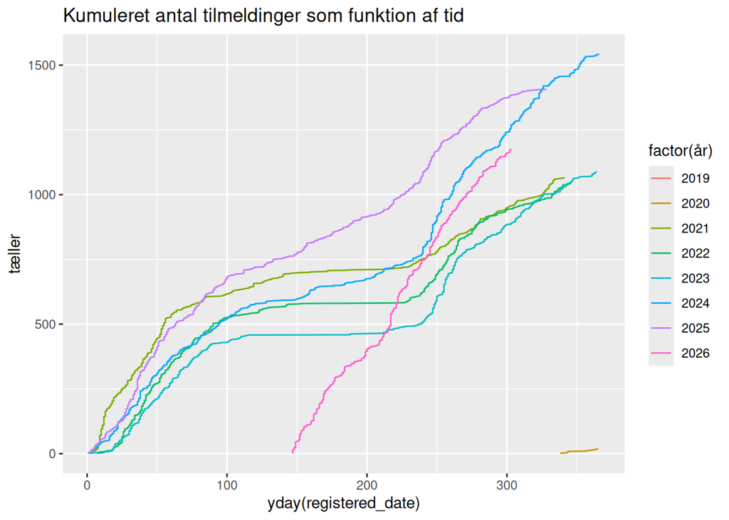

Ja, der skal pilles lidt ved akseetiketter og den slags.